# exploration_template

## Prosper Loan Exploration

### Preliminary Wrangling

```python
# importing require packages for prosper loan exploration
from zipfile import ZipFile
import pandas as pd
import numpy as np
import matplotlib.pyplot as plt
%matplotlib inline
import seaborn as sb
import warnings
```

### Accessing the Data

```python
#accessing data using pandas read_csv function and storing values in df variable
df = pd.read_csv('prosperLoanData.csv')
```

```python
warnings.filterwarnings('ignore')
```

```python
# copying from original data to data_clean variable, because it doesn't affect the original datasets
df_clean = df.copy()
```

```python
df_clean.shape
```

```
(113937, 81)
```

```python
df_clean.head()
```

|  | ListingKey | ListingNumber | ListingCreationDate | CreditGrade | Term | LoanStatus | ClosedDate | BorrowerAPR | BorrowerRate | LenderYield | ... | LP_ServiceFees | LP_CollectionFees | LP_GrossPrincipalLoss | LP_NetPrincipalLoss | LP_NonPrincipalRecoverypayments | PercentFunded | Recommendations | InvestmentFromFriendsCount | InvestmentFromFriendsAmount | Investors |
| --- | --- | --- | --- | --- | --- | --- | --- | --- | --- | --- | --- | --- | --- | --- | --- | --- | --- | --- | --- | --- | --- |
| 0 | 1021339766868145413AB3B | 193129 | 2007-08-26 19:09:29.263000000 | C | 36 | Completed | 2009-08-14 00:00:00 | 0.16516 | 0.1580 | 0.1380 | ... | -133.18 | 0.0 | 0.0 | 0.0 | 0.0 | 1.0 | 0 | 0 | 0.0 | 258 |
| 1 | 10273602499503308B223C1 | 1209647 | 2014-02-27 08:28:07.900000000 | NaN | 36 | Current | NaN | 0.12016 | 0.0920 | 0.0820 | ... | 0.00 | 0.0 | 0.0 | 0.0 | 0.0 | 1.0 | 0 | 0 | 0.0 | 1 |
| 2 | 0EE9337825851032864889A | 81716 | 2007-01-05 15:00:47.090000000 | HR | 36 | Completed | 2009-12-17 00:00:00 | 0.28269 | 0.2750 | 0.2400 | ... | -24.20 | 0.0 | 0.0 | 0.0 | 0.0 | 1.0 | 0 | 0 | 0.0 | 41 |
| 3 | 0EF5356002482715299901A | 658116 | 2012-10-22 11:02:35.010000000 | NaN | 36 | Current | NaN | 0.12528 | 0.0974 | 0.0874 | ... | -108.01 | 0.0 | 0.0 | 0.0 | 0.0 | 1.0 | 0 | 0 | 0.0 | 158 |
| 4 | 0F023589499656230C5E3E2 | 909464 | 2013-09-14 18:38:39.097000000 | NaN | 36 | Current | NaN | 0.24614 | 0.2085 | 0.1985 | ... | -60.27 | 0.0 | 0.0 | 0.0 | 0.0 | 1.0 | 0 | 0 | 0.0 | 20 |

5 rows × 81 columns

```python
df_clean.info()
```

```
<class 'pandas.core.frame.DataFrame'>
RangeIndex: 113937 entries, 0 to 113936
Data columns (total 81 columns):
ListingKey                             113937 non-null object
ListingNumber                          113937 non-null int64
ListingCreationDate                    113937 non-null object
CreditGrade                            28953 non-null object
Term                                   113937 non-null int64
LoanStatus                             113937 non-null object
ClosedDate                             55089 non-null object
BorrowerAPR                            113912 non-null float64
BorrowerRate                           113937 non-null float64
LenderYield                            113937 non-null float64
EstimatedEffectiveYield                84853 non-null float64
EstimatedLoss                          84853 non-null float64
EstimatedReturn                        84853 non-null float64
ProsperRating (numeric)                84853 non-null float64
ProsperRating (Alpha)                  84853 non-null object
ProsperScore                           84853 non-null float64
ListingCategory (numeric)              113937 non-null int64
BorrowerState                          108422 non-null object
Occupation                             110349 non-null object
EmploymentStatus                       111682 non-null object
EmploymentStatusDuration               106312 non-null float64
IsBorrowerHomeowner                    113937 non-null bool
CurrentlyInGroup                       113937 non-null bool
GroupKey                               13341 non-null object
DateCreditPulled                       113937 non-null object
CreditScoreRangeLower                  113346 non-null float64
CreditScoreRangeUpper                  113346 non-null float64
FirstRecordedCreditLine                113240 non-null object
CurrentCreditLines                     106333 non-null float64
OpenCreditLines                        106333 non-null float64
TotalCreditLinespast7years             113240 non-null float64
OpenRevolvingAccounts                  113937 non-null int64
OpenRevolvingMonthlyPayment            113937 non-null float64
InquiriesLast6Months                   113240 non-null float64
TotalInquiries                         112778 non-null float64
CurrentDelinquencies                   113240 non-null float64
AmountDelinquent                       106315 non-null float64
```

[output cut: 31 more lines]

```
LP_CustomerPayments                    113937 non-null float64
LP_CustomerPrincipalPayments           113937 non-null float64
LP_InterestandFees                     113937 non-null float64
LP_ServiceFees                         113937 non-null float64
LP_CollectionFees                      113937 non-null float64
LP_GrossPrincipalLoss                  113937 non-null float64
LP_NetPrincipalLoss                    113937 non-null float64
LP_NonPrincipalRecoverypayments        113937 non-null float64
PercentFunded                          113937 non-null float64
Recommendations                        113937 non-null int64
InvestmentFromFriendsCount             113937 non-null int64
InvestmentFromFriendsAmount            113937 non-null float64
Investors                              113937 non-null int64
dtypes: bool(3), float64(50), int64(11), object(17)
memory usage: 68.1+ MB
```

```python
n = list(df_clean)
```

```python
n1 = n[0:10]
```

```python
df_clean[n1]
```

[output not shown]

113937 rows × 10 columns

```python
n2 = n[10:20]
```

```python
df_clean[n2]
```

[output not shown]

113937 rows × 10 columns

```python
#from 81 columns most used columns are only selected
prosper = df_clean[['ListingNumber','CreditGrade','Term','LoanStatus','BorrowerAPR','BorrowerRate','LenderYield','ProsperRating (numeric)','ProsperScore','BorrowerState','Occupation','EmploymentStatus','EmploymentStatusDuration','LoanNumber','LoanOriginalAmount','IncomeRange','StatedMonthlyIncome','PercentFunded','InvestmentFromFriendsCount','InvestmentFromFriendsAmount','Investors','ProsperRating (Alpha)','IncomeVerifiable','DelinquenciesLast7Years','AmountDelinquent','DebtToIncomeRatio','CurrentDelinquencies']]
```

### What is the structure of your dataset?

There are 113937 rows and 81 columns, most variables are in objects, int, float, bool.

### What is/are the main feature(s) of interest in your dataset?

Interested more on borrower_rate, Loan_original_amount,and LenderYield and etc

### Data Wrangling

1) Drop the duplicates

#### Code

```python
prosper.duplicated().sum()
```

```
0
```

```python
#prosper[prosper['ListingNumber'].duplicated()]
prosper[prosper['ListingNumber']==1023355]
```

|  | ListingNumber | CreditGrade | Term | LoanStatus | BorrowerAPR | BorrowerRate | LenderYield | ProsperRating (numeric) | ProsperScore | BorrowerState | ... | PercentFunded | InvestmentFromFriendsCount | InvestmentFromFriendsAmount | Investors | ProsperRating (Alpha) | IncomeVerifiable | DelinquenciesLast7Years | AmountDelinquent | DebtToIncomeRatio | CurrentDelinquencies |
| --- | --- | --- | --- | --- | --- | --- | --- | --- | --- | --- | --- | --- | --- | --- | --- | --- | --- | --- | --- | --- | --- |
| 8 | 1023355 | NaN | 36 | Current | 0.0762 | 0.0629 | 0.0529 | 7.0 | 9.0 | IL | ... | 1.0 | 0 | 0.0 | 1 | AA | True | 0.0 | 0.0 | 0.25 | 0.0 |
| 9 | 1023355 | NaN | 36 | Current | 0.0762 | 0.0629 | 0.0529 | 7.0 | 11.0 | IL | ... | 1.0 | 0 | 0.0 | 1 | AA | True | 0.0 | 0.0 | 0.25 | 0.0 |

2 rows × 27 columns

```python
prosper.drop_duplicates('ListingNumber',inplace=True)
```

#### Test

```python
prosper.ListingNumber.duplicated().sum()
```

```
0
```

```python
# Taking average of CreditScoreRangeLower and CreditScoreRangeUpper  for Credit Score
prosper['Credit_score'] = df_clean.CreditScoreRangeLower + df_clean.CreditScoreRangeUpper/2
```

### 1) What is Prosper Loan Current Status ?

```python
prosper.LoanStatus.value_counts()
```

```
Current                   55730
Completed                 38061
Chargedoff                11992
Defaulted                  5018
Past Due (1-15 days)        800
Past Due (31-60 days)       361
Past Due (61-90 days)       311
Past Due (91-120 days)      304
Past Due (16-30 days)       265
FinalPaymentInProgress      203
Past Due (>120 days)         16
Cancelled                     5
Name: LoanStatus, dtype: int64
```

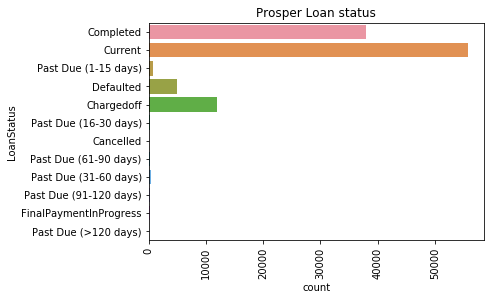

```python
sb.countplot(data = prosper,y='LoanStatus');
plt.xticks(rotation = 90);
plt.title('Prosper Loan status');
```

Answer: Status of prosper loan were: Current active user of loan prosper are 55730, Completed from prosper loan 38061, Chargedoff from prosper loan11992, Defaulted from prosper loan 5018, Past Due (1-15 days) from prosper loan 800, Past Due (31-60 days) from prosper loan 361, Past Due (61-90 days) from prosper loan 311, Past Due (91-120 days) from prosper loan 304, Past Due (16-30 days) from prosper loan 265, FinalPaymentInProgress from prosper loan 203, Past Due (>120 days) from prosper loan 16, Cancelled from prosper loan 5,

### 2)Which types of people uses prosper loan ?

```python
#sb.countplot(data = prosper,x=prosper.LoanOriginalAmount)
```

```python
n = prosper.LoanOriginalAmount.value_counts()
```

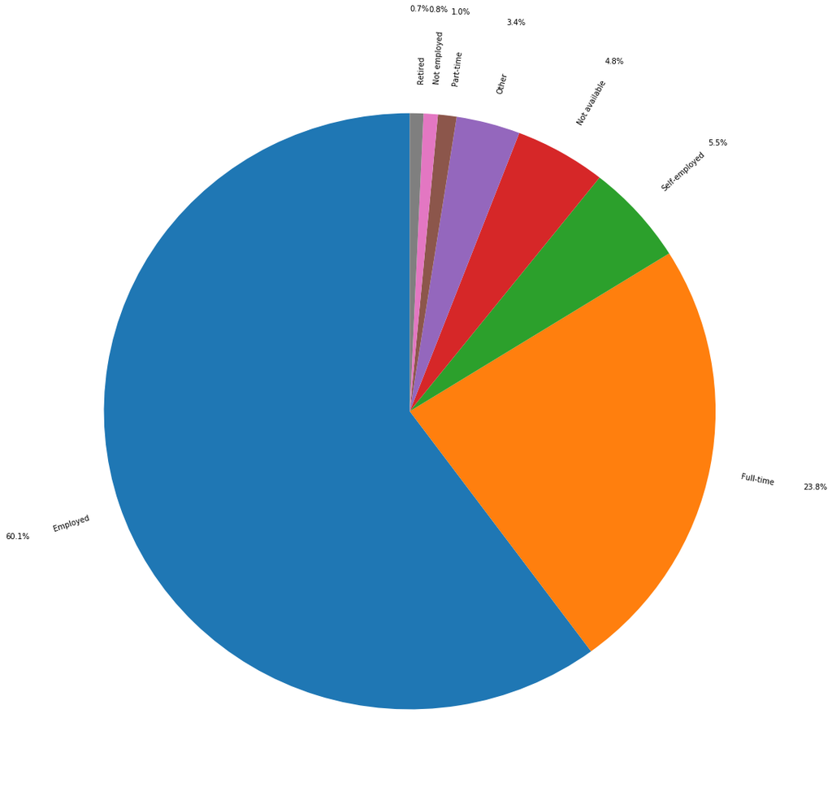

```python
com = prosper.EmploymentStatus.value_counts()
plt.figure(figsize=[18,18],);
plt.pie(com,labels=com.index,startangle=90,rotatelabels=True,autopct='%1.1f%%',pctdistance=1.35);
```

Answer:employes types of people use more prosper loan of 60.1 and the second highest is full time employes uses around 23.8,and second least user are not employed around 0.8 and least beneficial are retired people around 0.7.